# PCA Tutorial

### Understanding PCA visually

PCA can be understood as a rotation of the data. The data are rotated in such a way that it varies as much as possible on the horizonal axis. The horizontal axis is the first principal component (PC1), and the vertical axis is the second principal component (PC2).

It’s easiest to understand PCA when there are only two variables, so for now we’ll only consider petal length and sepal length. Below is a scatterplot of petal length and sepal length. The origin of the axes is in the middle of the scatterplot because I standardized both variables to have means of 0 and variances of 1. Each point represents the sepal length and petal length measurements of one flower. **Click and drag the scatterplot below to rotate it** so that the data are as spread out as possible on the horizonal axis. In other words, rotate the scatterplot so that the data has maximum variance on the PC1 axis.

**Click for Hint**

Another way to think of the problem is to imagine the line of best fit for the data. The variance along the line of best fit is maximized because the residuals are minimized. Therefore, you should rotate the scatter plot so that the line of best fit is horizontal.

Click and drag to rotate the plot below!

[interactive chart not shown]

Compare your solution to the PCA biplot below. Did you find the same solution?

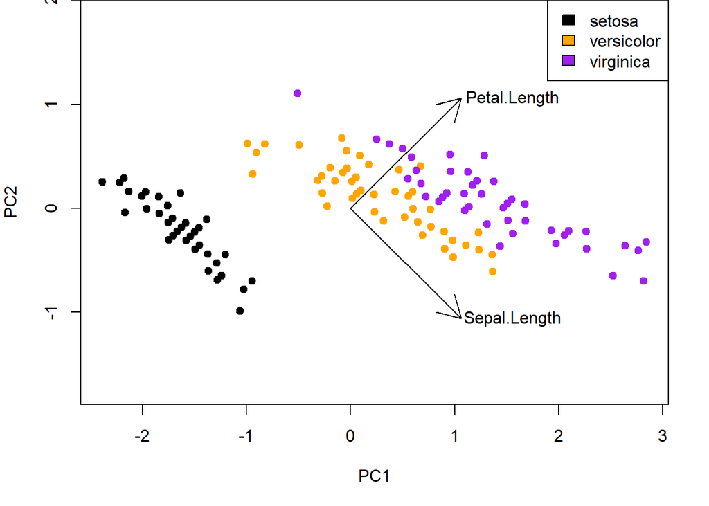

The PCA becomes more interesting as we add a third variable. As before, **click and drag the 3D scatterplot below to rotate it** so that the data has the most variance on the horizontal axis. Then, rotate the scatterplot on its horizontal axis so that the data has the second-most variance on the vertical axis.

Click and drag to rotate the plot below!

[interactive chart not shown]

Did you find the same solution as the PCA biplot, below? If not, try rotating the scatterplot so that it matches the PCA.

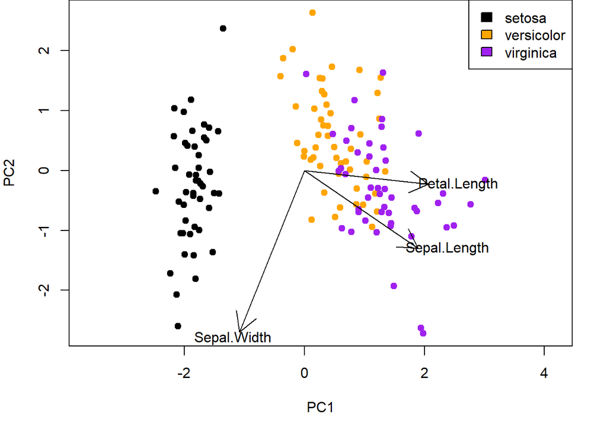

As you can see, the PCA is simply a rotation of the data into a new coordinate system. The new coordinate system is defined by the principal component axes. By looking at the black arrows that represent the original variables, we can see the relationship between the old and new coordinate systems. When we perform a PCA on data with more variables, the principles are still the same. Like with the 3D scatterplot above, we can still understand the PCA biplot as 2D view of the data from a particular angle in multidimensional space. The only difference is that the multidimensional space has more than three dimensions, which can hurt your brain if you think too much about it!

### How does the math work?

Now that we have explored a visual understanding of PCA, let’s look a bit at the math. We return to two dimensions to keep things simple:

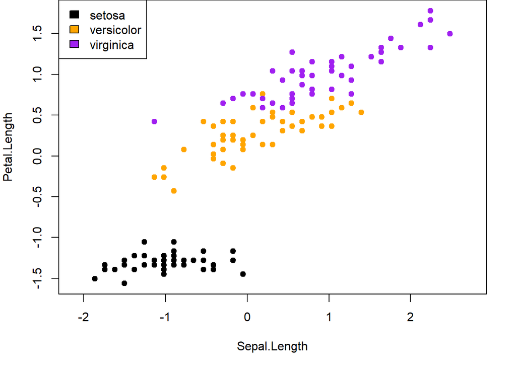

We start by making covariance matrix of the two scaled variables. In a covariance matrix, the values on the diagonal represent variances and other values represent covariances:

```
##              Sepal.Length Petal.Length
## Sepal.Length    1.0000000    0.8717538
## Petal.Length    0.8717538    1.0000000
```

The variance of Sepal.Length and Petal.Length are 1 because I standardized them. The covariance of the two variables is 0.8717538, meaning that they increase together (as we can see in the scatterplot).

As we saw above, PCA defines a new coordinate system for the data and we can understand the change in coordinate system as a rotation of the data. Another way to look at it is that the new variables (principal components) are made up of different combinations of the original variables, called linear combinations. Mathematically, the arrows in a biplot are visualizations of “eigenvectors”, which are a set of vectors that describe the relationship between the old and new coordinate systems. The change in coordinate system does not change the number of dimensions, so there are the same number of principal components as there are original variables (in this case, two).

The new coordinate system and its corresponding eigenvectors are chosen such that the data has maximum possible variance on the first principal component axis. The maximum possible variance occurs when the covariance is 0. (Think back to the 2D scatterplot that you rotated above: you may have noticed that the greatest spread in the horizonal axis occured when the data showed no upwards or downwards trend – in other words, a covariance of 0.) Therefore, the eigenvectors are chosen such that the covariances are 0 in the new coordinate system. This means that all the values in the covariance matrix are 0 except for those on the diagonal, and so we call this a diagonalized matrix.

```
##          PC1       PC2
## PC1 1.871754 0.0000000
## PC2 0.000000 0.1282462
```

The numbers on the diagonal are called “eigenvalues”. The eigenvalues are the variances of the data on each principal components axis. We can consider the eigenvalues to be the amount of variance in the data that is explained by each principal component. The principal component with the largest eigenvalue is called “PC1”, the principal component with the second largest eigenvalue is called “PC2”, and so on (when there are more than two dimensions).

### How to do a PCA in R

We will perform a PCA using R, a free software environment for statistics and graphics that is widely used by ecologists. To perform a PCA in R, we use the function *prcomp*. So far, we have performed the PCA on two variables (Petal.Length and Sepal.Length) and three varaibles (we added in Sepal.Width). We performed the PCA on these smaller subsets of the Iris dataset to help us to understand how PCA works. Now that we have developed a basic visual and mathematical understanding, we will perform the PCA on all four of the continuous variables in the Iris dataset (we will add in Petal.Width).

We pass our data to the *prcomp* function as the first argument. We set *scale* and *center* to TRUE. This standardizes the variables so that each variable has a mean of 0 and a variance of 1. This is an important step because the principal components maximize the variance. If we don’t want the PCA to be dependent on the scales of each variable, we need to make sure they are scaled the same.

```r
iris.pca <- prcomp(iris[,1:4],scale=TRUE,center=TRUE)
```

We can look at a summary of the results using the *summary* function.

```r
summary(iris.pca)
```

```
## Importance of components:
##                           PC1    PC2     PC3     PC4
## Standard deviation     1.7084 0.9560 0.38309 0.14393
## Proportion of Variance 0.7296 0.2285 0.03669 0.00518
## Cumulative Proportion  0.7296 0.9581 0.99482 1.00000
```

Notice that there are four principal components because there were four original variables. Each component explains a percentage of the total variance in the data, calculated from the eigenvalues. Since we standardized the variables to have a variance of 1, the total variance of the data is 4. PC1 explains 73%, PC2 explains 22.9%, etc.

**Test your understanding:** What percent of the total variance in the data is explained by PC3?

**Click for Answer**

The proportion of total variance explained by PC3 is 0.03669, which is 3.7%.

If we want to reduce the dimensions of our data, we should discard the principal components after some cutoff. There are various approaches for choosing a cutoff, but that’s beyond the scope of this tutorial. Generally, you should enough dimensions to capture the large majority of the variance in your data. For instance, we might discard principal component 4 (and maybe 3 as well). PC1 and PC2 together explain 95.8% of the total variance in the data, and P1, P2, and PC3 together explain 99.5% of the total variance. The final principal component only explains an additional 0.5%. If we discard PC3 and PC4, we reduce the dimensions of our data while losing very little of the variance in the data.

Using the function, *structure*, we can look at more information about the PCA.

```r
structure(iris.pca)
```

```
## Standard deviations (1, .., p=4):
## [1] 1.7083611 0.9560494 0.3830886 0.1439265
##
## Rotation (n x k) = (4 x 4):
##                     PC1         PC2        PC3        PC4
## Sepal.Length  0.5210659 -0.37741762  0.7195664  0.2612863
## Sepal.Width  -0.2693474 -0.92329566 -0.2443818 -0.1235096
## Petal.Length  0.5804131 -0.02449161 -0.1421264 -0.8014492
## Petal.Width   0.5648565 -0.06694199 -0.6342727  0.5235971
```

The “Rotation” table columns give the eigenvectors for each of the principal components. As we saw above, the eigenvectors are visualized in biplots as arrows and they describe how the axes of the original variables are oriented relative to the principal component axes.

We will make our own biplot using the *plot* function. We can start by plotting the PC1 and PC2 values of each iris individual as a point. These values are stored, respectively, in the first and second column of iris.pca$x.

**Test your understanding:** What does it mean if two points are far from each other on the biplot? What does it mean if two points are close together?

**Click for Answer**

Two points far apart on the biplot represent two plant individuals with dissimilar flower morphology. Two points close together on the biplot represent two plant individuals with similar flower morphology.

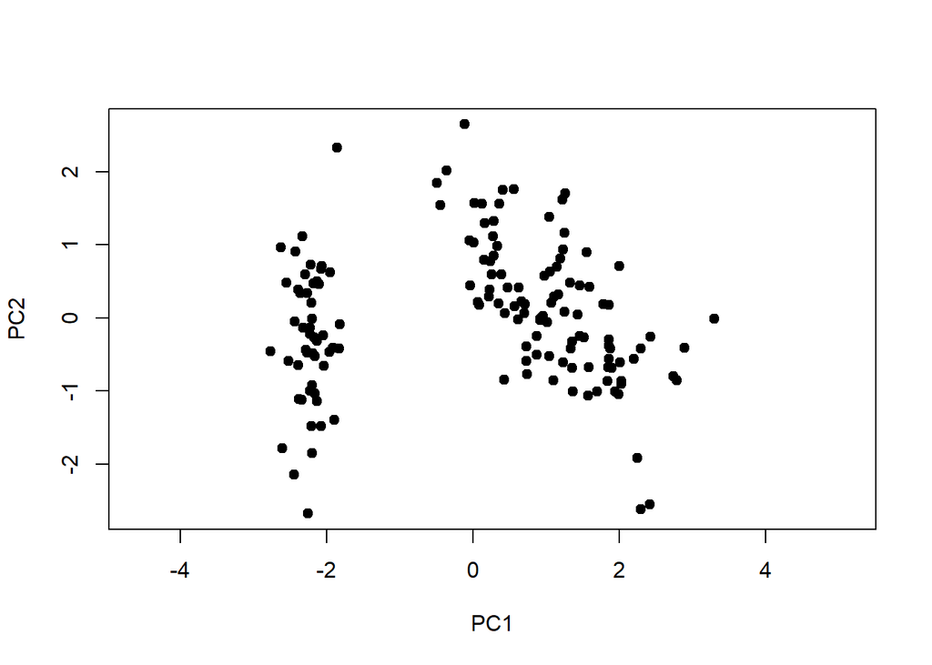

```r
plot(iris.pca$x[,1],iris.pca$x[,2],pch=19,xlab="PC1",ylab="PC2",asp=1)
```

Suppose we are interested to know if the three iris species differ in their flower morphology. One way we can explore that question is by colouring the individuals by species in the graph. This will not allow us to test hypotheses about differences between the species, but it will allow us to explore and visualize possible patterns. In the graph below, we add colour and a legend.

**Test your understanding:** If two species differ in their flower morphology, what will you see on the biplot? What will you see if they do not differ in their flower morphology?

**Click for Answer**

If two species differ completely in their flower morphology then the two “clouds” of points representing each species will not overlap with each other. The farther apart the “clouds”, the more disimilar the species in their flower moprhology. If two species are completely the same in their flower morphology, their “clouds” will fully overlap. In between these two extremes, the two species could be similar but not completely the same in their flower morphology, in which case the two “clouds” will partially overlap.

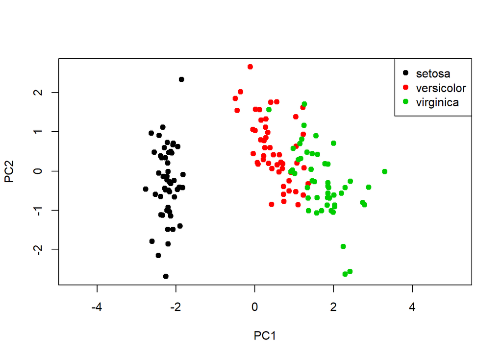

```r
plot(iris.pca$x[,1],iris.pca$x[,2],pch=19,xlab="PC1",ylab="PC2",asp=1,col=iris$Species)
legend("topright",legend = unique(iris$Species), col=1:3, pch=19)
```

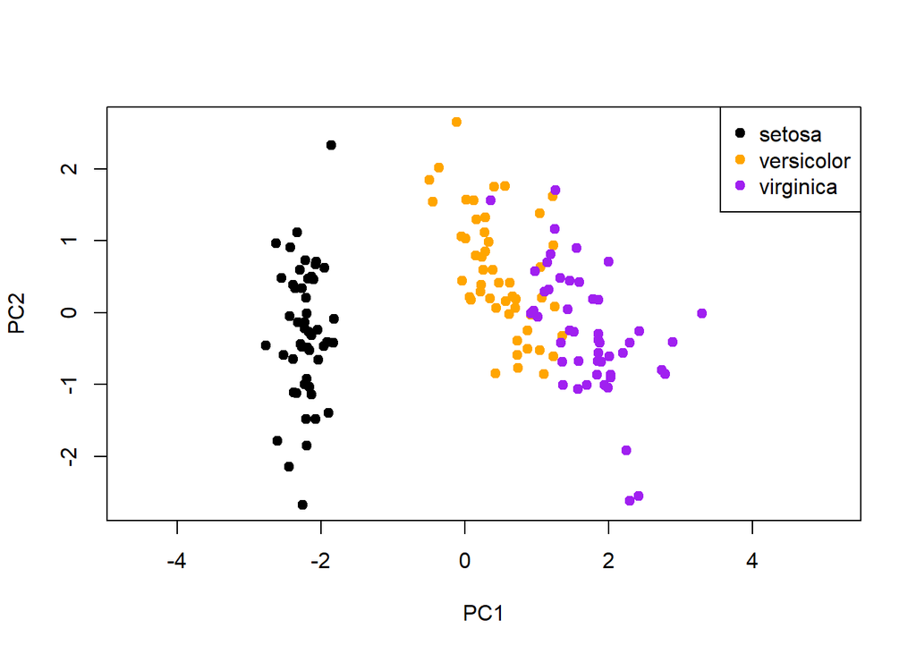

```r
colour = ifelse(iris$Species=="setosa", "black", ifelse(iris$Species=="versicolor","orange", "purple"))
plot(iris.pca$x[,1],iris.pca$x[,2],pch=19,xlab="PC1",ylab="PC2",asp=1, col=colour)
legend("topright",legend = unique(iris$Species), col=unique(colour), pch=19)
```

**Test your understanding:** What does the biplot suggest about how the three species differ in their flower morphology?

**Click for Answer**

The flower morphology of *Iris setosa* is completely different from the flower morphology of *Iris versicolor* and *Iris virginica*. The flower morphology of *Iris versicolor* and *Iris virginica* is similar, but not completely the same.

Next, we’ll add arrows and text to visualize the eigenvectors. We obtain the eigenvector values from the “Rotation” table.

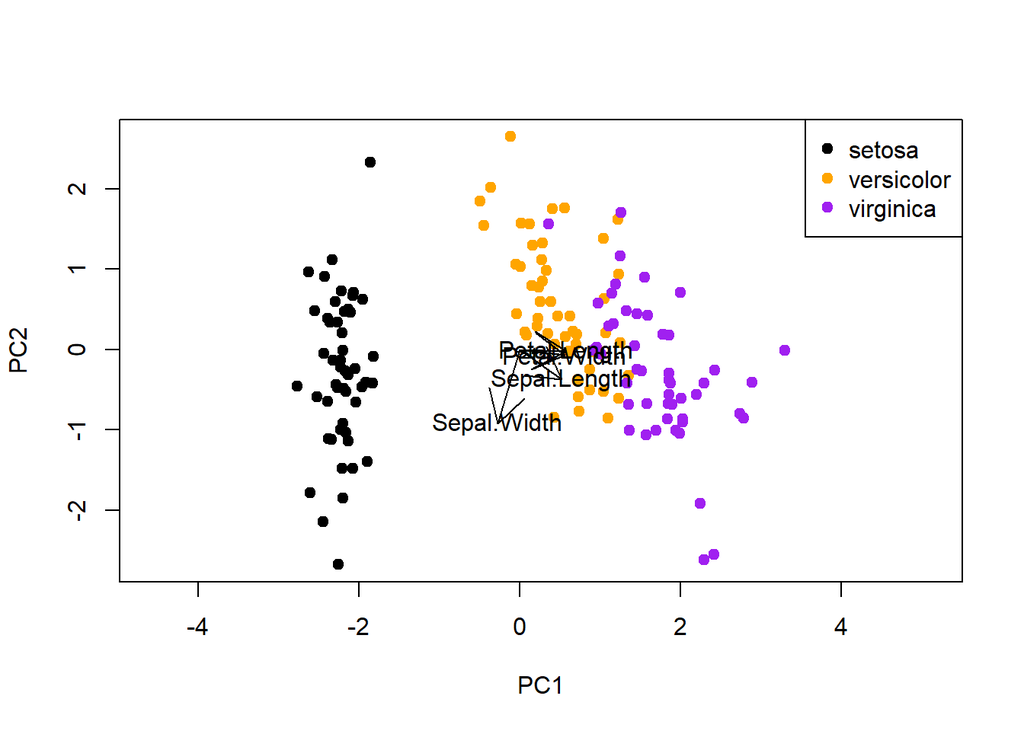

```r
colour = ifelse(iris$Species=="setosa", "black", ifelse(iris$Species=="versicolor","orange", "purple"))
plot(iris.pca$x[,1],iris.pca$x[,2],pch=19,xlab="PC1",ylab="PC2",asp=1, col=colour)
arrows(x0=c(0,0,0,0),y0=c(0,0,0,0),x1=iris.pca$rotation[,1],y1=iris.pca$rotation[,2])
text(x=iris.pca$rotation[,1],y=iris.pca$rotation[,2],colnames(iris[,1:4]))
legend("topright",legend = unique(iris$Species), col=unique(colour), pch=19)
```

The labels and arrows are crowded together and difficult to read, so we can extend them by multiplying the rotation values by some number (I found that 3 looks pretty good). The angle between the arrows and their relative length are the important things; we can change the absolute length of the arrows without affecting our interpretation of the biplot.

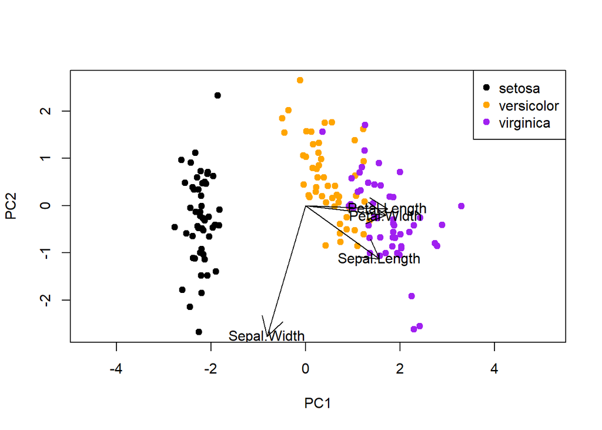

```r
colour = ifelse(iris$Species=="setosa", "black", ifelse(iris$Species=="versicolor","orange", "purple"))
plot(iris.pca$x[,1],iris.pca$x[,2],pch=19,xlab="PC1",ylab="PC2",asp=1, col=colour)
arrows(x0=c(0,0,0,0),y0=c(0,0,0,0),x1=iris.pca$rotation[,1]*3,y1=iris.pca$rotation[,2]*3)
text(x=iris.pca$rotation[,1]*3,y=iris.pca$rotation[,2]*3,colnames(iris[,1:4]))
legend("topright",legend = unique(iris$Species), col=unique(colour), pch=19)
```

**Test your understanding:** Why are the Petal.Length and Petal.Width arrows so similar? Why is the Sepal.Width arrow pointing in a different direction from the other arrows?

**Click for Answer**

If two variables were negatively correlated, then their arrows would point in opposite directions on the biplot.

**Test your understanding:** How does *Iris setosa* differ from *Iris versicolor* in its flower morphology?

**Click for Answer**

*Iris setosa* and *Iris versicolor* differ on the PC1 axis, with *Iris versicolor* having higher PC1 values. Petal.Length, Petal.Width, and Sepal.Length increase on the PC1 axis. Sepal.Width decreases slightly on the PC1 axis. Therefore, *Iris versicolor* tends to have greater Petal.Length, Petal.Width, and Sepal.Length but slightly smaller Sepal.Width than *Iris setosa*.

Looking at the species means using the *aggregate* function confirms our interpretation:

```r
aggregate(. ~ Species, data = iris, mean)
```

```
##      Species Sepal.Length Sepal.Width Petal.Length Petal.Width
## 1     setosa        5.006       3.428        1.462       0.246
## 2 versicolor        5.936       2.770        4.260       1.326
## 3  virginica        6.588       2.974        5.552       2.026
```

How does flower morphology differ among *Iris setosa* individuals?

### Further reading

- I highly recommend you read [the top answer to this StackExchange question](https://stats.stackexchange.com/questions/2691/making-sense-of-principal-component-analysis-eigenvectors-eigenvalues). The author gives a brilliant explanation of PCA by imagining a dinner table conversation.
- This [website](http://setosa.io/ev/principal-component-analysis/) gives additional interactive visualizations for understanding PCA.
- PCA is often an inappropriate choice for analyzing species abundance data. [This website](http://ordination.okstate.edu/PCA.htm) does a good job of explaining why.
- If you’re interested in understanding the math behind PCA in more detail, [this is a great tutorial](http://www.cs.otago.ac.nz/cosc453/student_tutorials/principal_components.pdf) that starts from the basics (variance, matrix multiplication, etc.) and works its way up.

## Assignment

As with previous tutorial assignments, please hand in your assignment as a pdf document created using RMarkdown. For any code, set echo=TRUE so that it is visible. Submit your document in the “PCA tutorial” folder in Moodle.

### Part I: Comprehension

The following questions are about the paper below, which you were asked to read before the tutorial.

Garnier, E., Cortez, J., Billès, G., Navas, M. L., Roumet, C., Debussche, M., … & Neill, C. (2004). Plant functional markers capture ecosystem properties during secondary succession. Ecology, 85(9), 2630-2637. [Link](https://esajournals.onlinelibrary.wiley.com/doi/10.1890/03-0799)

1. The authors state that they performed the PCA on standardized data. Why was it important for them to mention that the data were standardized?
2. In Figure 2, the authors present a much simpler graph than the one I made in this tutorial. Why do you think the authors decided to make their figure the way they did? Do you think it was a good decision, or would you make the figure differently? Justify your answer. The authors didn’t plot data points, but if they did, how many points would there be and why?
3. Based on Figure 2, how did the vinyards change as time passed since their abdonment? In your own words, how do the authors explain these changes ecologically?
4. The following information should be included when reporting a PCA. Quote from the paper to show how the authors communicated each piece of information:
   1. The reason(s) for doing a PCA.
   2. How the PCA was performed (standardization, software used, etc.).
   3. The variance (or “inertia”) explained by each principal component axis.
   4. How the original variables relate to each other and to the principal component axes.

### Part II: Student data

Before the tutorial, you were asked to complete a [survey](https://forms.gle/CbbTexyC7rMu1PVVA). This survey involved completing six short tasks on the website https://www.humanbenchmark.com/. The data collected from the survey is available [here](https://docs.google.com/spreadsheets/d/1AD2fgIpdxp2Bj71GOKs12U8QvUHzCYSqYqyYFvKVXxA/edit?usp=sharing). Download the data from the Google Spreadsheet as a csv file by going to File > Download > Comma-separated values. Open the downloaded file in Excel and rename the columns with short names that don’t contain spaces (e.g., change “Can you play a musical instrument?” to “musician”). If any of the values are blank or nonsensical, replace them with “NA”.

Think about how might the task performance variables correlate with each other. Choose one demographic variable and think about how it might affect task performance. (The “demographic variables” are the ones about gender, and whether the student is a musician, athlete, or gamer.) Load the data in R and explore the data using functions like *summary*, *aggregate*, and *plot*. You don’t need to include this exploration in your report, but it will help you to understand the PCA. Perform a PCA on the six task performance variables. Make a biplot of the PCA and colour the points by your chosen demographic variables. Report the results and discuss what they mean.

**To include in your report:**

1. How do you think the task performance variables will correlate with each other? How do you think your chosen demographic variable will correlate with task performance?
2. Methods: A paragraph describing the methods used to gather the data and perform the PCA. Use Part I as a guide for how to describe the PCA methods.
3. Figure: A PCA biplot, coloured by your chosen demographic variable and including a figure caption. Include the R code used to generate the PCA and the plot.
4. Results: A short paragraph reporting the PCA results. Again, use Part I as a guide for what to include in the results.
5. Discussion: Interpret the results (300-400 words). Discuss how performance on different tasks correlate to each other and suggest what may cause these correlations. Discuss how your chosen demographic variable correlates with task performance. Does what you see in the PCA align with your expectations (Question 1)? Include any other interesting insights about the data you may have gained from the PCA.

### Evaluation

For each question, I indicate below the criteria that will be evaluated and the point allocation. The performance descriptions for the criteria are given in the statistcal literacy rubric in the course outline. (The course outline is available as a pdf here.)

Part I:

1. Interpretation, communication; 1 pt
2. Interpretation, communication; 1 pt
3. Interpretation, communication; 1 pt
4. Accuracy (i.e., did the student choose the correct quotes); 0.25 pts each x 4 = 1 pt

Part II:

1. Communication; 2 pts
2. Communication; 2 pts
3. Calculation, representation; 2 pts
4. Interpretation, communication; 2 pts
5. Application/analysis, communication; 2 pts

Total = 14 pts